# Recommendation systems (Part 1)

Stefano Galelli

Term 6, 2020

First, we prepare the working environment.

```r
rm(list=ls()) # Clear the environment
setwd("~/Documents/SUTD/Term 6/TAE/W11")
# setwd("...")  # Setup the working directory
```

# 1 MovieLens dataset

The data come from [grouples](https://grouplens.org), a research lab in the Department of Computer Science and Engineering at the University of Minnesota.

We begin by loading the data. Because the dataset contains strings, we use the option `stringsAsFactors=FALSE` (so as to make sure that character vectors are NOT converted into factors). The dataframe consists of two variables with 8569 movies with movieID and title.

```r
movies <- read.csv("movies.csv", stringsAsFactors = FALSE)
str(movies)
```

```
## 'data.frame':    8569 obs. of  2 variables:
##  $ movieId: int  1 2 3 4 5 6 7 8 9 10 ...
##  $ title  : chr  "Toy Story (1995)" "Jumanji (1995)" "Grumpier Old Men (1995)" "Waiting to Exhale (1995)" ...
```

A quick look at the dataframe:

```r
head(movies) # First part of the dataframe
```

```
##   movieId                              title
## 1       1                   Toy Story (1995)
## 2       2                     Jumanji (1995)
## 3       3            Grumpier Old Men (1995)
## 4       4           Waiting to Exhale (1995)
## 5       5 Father of the Bride Part II (1995)
## 6       6                        Heat (1995)
```

```r
summary(movies) # Summary of the data
```

```
##     movieId          title
##  Min.   :     1   Length:8569
##  1st Qu.:  2706   Class :character
##  Median :  5734   Mode  :character
##  Mean   : 24463
##  3rd Qu.: 44889
##  Max.   :129454
```

The movie genre is contained in a different file. To read it, we use the following commands:

```r
# Count the number of fields separated by "|" in each row of genres.csv
countfields <- count.fields("genres.csv", sep = "|")

# The first movie, for example has 5 genres listed
countfields[1]
```

```
## [1] 5
```

```r
# With this command, we can see that movies have from 1 to 7 genres listed
min(countfields)
```

```
## [1] 1
```

```r
max(countfields)
```

```
## [1] 7
```

```r
# Now, we load genres.csv. The command creates a dataframe with 8569 observations and 7 variables with column names X1 ... X7.
genres <- read.csv("genres.csv", header = FALSE, sep = "|", col.names = c("X1", "X2", "X3", "X4", "X5", "X6", "X7"), stringsAsFactors = TRUE)
# Note that each variable has different number of levels
str(genres)
```

```
## 'data.frame':    8569 obs. of  7 variables:
##  $ X1: Factor w/ 18 levels "Action","Adventure",..: 2 2 5 5 5 1 5 2 1 1 ...
##  $ X2: Factor w/ 19 levels "","Adventure",..: 3 4 15 8 1 6 15 4 1 2 ...
##  $ X3: Factor w/ 18 levels "","Animation",..: 3 8 1 14 1 16 1 1 1 16 ...
##  $ X4: Factor w/ 16 levels "","Children",..: 3 1 1 1 1 1 1 1 1 1 ...
##  $ X5: Factor w/ 14 levels "","Comedy","Crime",..: 5 1 1 1 1 1 1 1 1 1 ...
##  $ X6: Factor w/ 10 levels "","Fantasy","IMAX",..: 1 1 1 1 1 1 1 1 1 1 ...
##  $ X7: Factor w/ 6 levels "","IMAX","Mystery",..: 1 1 1 1 1 1 1 1 1 1 ...
```

For this class, we need to work with a matrix having 8,569 rows and a number of columns equal to the number of genres. For each cell, we want to know whether a certain genre is associated (1) or not (0) to a certain movie. This requires some processing of the data contained in `genres`. We use a dedicated function to do it.

```r
# Source and run the function
source('process_genre_data.R')
M <- process_genre_data(genres)
```

Last step, we create a dataframe (named `Data`) with movie title and classification.

```r
Data <- as.data.frame(M)
Data$title <- movies$title
Data <- Data[, -19] # Drops the 19th column, which corresponds to the "" category
```

We are now ready for our clustering exercise.

# 2 Hierarchical clustering

To run hierarchical clustering in R, we must follow two steps. First, we use the function `dist` to calculate the distance between movies using the first 19 columns (genres of movies).

```r
distances <- dist(Data[, 1:19], method = "euclidean")
dim(Data)
```

```
## [1] 8569   20
```

```r
# length(distances)
```

Note that we computed 3.670959610^{7} distances.

Then, we execute hierarchical clustering. We use Ward’s distance method to find compact clusters.

```r
clusterMovies1 <- hclust(distances, method = "ward.D2")
```

Plot the dendrogram. We have several movies, so the lists at the bottom cannot be read.

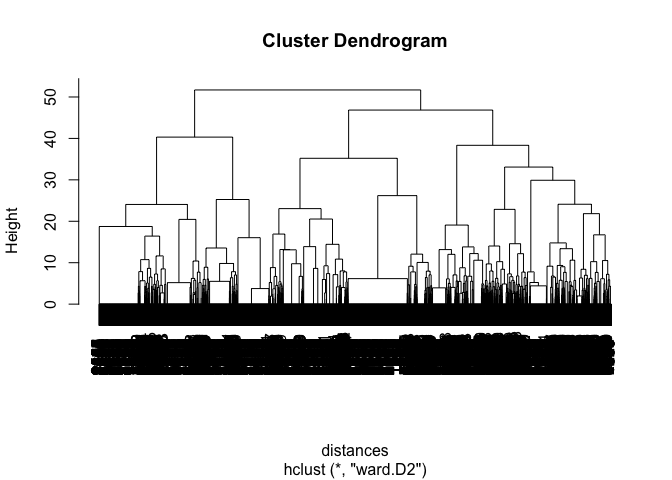

```r
plot(clusterMovies1)
```

Let’s now cut the dendrogram into 10 clusters and compute the average value across the clusters for the Action variable. Higher value indicates many movies in the clusters are action movies.

```r
clusterGroups1 <- cutree(clusterMovies1, k = 10)
tapply(Data[, 1], clusterGroups1, mean)
```

```
##           1           2           3           4           5           6
## 0.179775281 0.000000000 0.126376812 0.382575758 0.365241636 0.110604333
##           7           8           9          10
## 0.000000000 0.098993289 0.006116208 0.394607843
```

Create a matrix “Cat1” where rows denote categories and columns indicate clusters

```r
Cat1 <- matrix(0, nrow = 19, ncol = 10)
for(i in 1:19)
{Cat1[i,] <- tapply(Data[,i], clusterGroups1, mean)}
rownames(Cat1) <- colnames(Data)[1:19]
Cat1
```

```
##                    [,1]        [,2]         [,3]         [,4]        [,5]
## Action      0.179775281 0.000000000 0.1263768116 0.3825757576 0.365241636
## Adventure   0.457865169 0.000000000 0.0684057971 0.0340909091 0.396840149
## Animation   0.363764045 0.005725191 0.0023188406 0.0015151515 0.045539033
## Children    0.526685393 0.013358779 0.0075362319 0.0015151515 0.094795539
## Comedy      0.532303371 1.000000000 0.9304347826 0.0128787879 0.121747212
## Crime       0.012640449 0.000000000 0.1460869565 0.5318181818 0.018587361
## Documentary 0.000000000 0.000000000 0.0133333333 0.0022727273 0.005576208
## Drama       0.191011236 0.431297710 0.3408695652 0.6500000000 0.263940520
## Fantasy     0.620786517 0.000000000 0.0081159420 0.0060606061 0.020446097
## Film-Noir   0.000000000 0.000000000 0.0005797101 0.0621212121 0.001858736
## Horror      0.016853933 0.000000000 0.0040579710 0.0348484848 0.116171004
## Musical     0.132022472 0.000000000 0.1176811594 0.0007575758 0.006505576
## Mystery     0.036516854 0.000000000 0.0255072464 0.1628787879 0.036245353
## Romance     0.139044944 1.000000000 0.0626086957 0.0022727273 0.027881041
## Sci-Fi      0.085674157 0.000000000 0.0034782609 0.0242424242 0.568773234
## Thriller    0.005617978 0.000000000 0.0626086957 0.6446969697 0.263011152
## War         0.007022472 0.000000000 0.0023188406 0.0037878788 0.005576208
## Western     0.005617978 0.000000000 0.0000000000 0.0030303030 0.192379182
## IMAX        0.071629213 0.000000000 0.0028985507 0.0083333333 0.057620818
##                    [,6]         [,7]        [,8]        [,9]      [,10]
## Action      0.110604333 0.0000000000 0.098993289 0.006116208 0.39460784
## Adventure   0.025085519 0.0000000000 0.075503356 0.000000000 0.21323529
## Animation   0.007981756 0.0159362550 0.001677852 0.000000000 0.00000000
## Children    0.001140251 0.0039840637 0.003355705 0.000000000 0.00000000
## Comedy      0.168757127 0.0029880478 0.046979866 0.110091743 0.10294118
## Crime       0.031927024 0.0000000000 0.109060403 0.000000000 0.02450980
## Documentary 0.009122007 0.0009960159 0.000000000 1.000000000 0.03431373
## Drama       0.164196123 1.0000000000 0.845637584 0.042813456 0.74019608
## Fantasy     0.103762828 0.0000000000 0.016778523 0.000000000 0.00245098
## Film-Noir   0.000000000 0.0000000000 0.010067114 0.000000000 0.00000000
## Horror      0.916761688 0.0000000000 0.008389262 0.000000000 0.00245098
## Musical     0.004561003 0.0000000000 0.008389262 0.003058104 0.00245098
## Mystery     0.193842645 0.0000000000 0.073825503 0.000000000 0.00245098
## Romance     0.019384265 0.0039840637 1.000000000 0.003058104 0.02696078
## Sci-Fi      0.095781072 0.0009960159 0.005033557 0.000000000 0.01470588
## Thriller    0.489167617 0.0000000000 0.145973154 0.000000000 0.10294118
## War         0.002280502 0.0029880478 0.078859060 0.000000000 0.94607843
## Western     0.001140251 0.0000000000 0.052013423 0.000000000 0.02696078
## IMAX        0.012542759 0.0000000000 0.000000000 0.030581040 0.00245098
```

Looking at `Cat1`, we can infer that the 10 clusters are organized as follows:

- Cluster 1: Fantasy, Comedy, Children, Adventure
- Cluster 2: Romance, Comedy, Drama
- Cluster 3: Comedy, Drama
- Cluster 4: Drammar, Thriller, Crime
- Cluster 5: Sci-fi, Adventure, Action
- Cluster 6: Horror, Thriller
- Cluster 7: Drama
- Cluster 8: Romance, Drama
- Cluster 9: Documentary
- Cluster 10: War, Drama, Action

Let’s take a look at various movies

```r
# subset(Data$title, clusterGroups1==6)
subset(Data, movies$title=="Grand Budapest Hotel, The (2014)")
```

```
##      Action Adventure Animation Children Comedy Crime Documentary Drama Fantasy
## 8418      0         0         0        0      1     0           0     1       0
##      Film-Noir Horror Musical Mystery Romance Sci-Fi Thriller War Western IMAX
## 8418         0      0       0       0       0      0        0   0       0    0
##                                 title
## 8418 Grand Budapest Hotel, The (2014)
```

```r
clusterGroups1[8418]
```

```
## [1] 3
```

```r
subset(Data, movies$title=="Moneyball (2011)")
```

```
##      Action Adventure Animation Children Comedy Crime Documentary Drama Fantasy
## 7925      0         0         0        0      0     0           0     1       0
##      Film-Noir Horror Musical Mystery Romance Sci-Fi Thriller War Western IMAX
## 7925         0      0       0       0       0      0        0   0       0    0
##                 title
## 7925 Moneyball (2011)
```

```r
clusterGroups1[7925]
```

```
## [1] 7
```

```r
subset(Data, movies$title=="X-Men: First Class (2011)")
```

```
##      Action Adventure Animation Children Comedy Crime Documentary Drama Fantasy
## 7849      1         1         0        0      0     0           0     0       0
##      Film-Noir Horror Musical Mystery Romance Sci-Fi Thriller War Western IMAX
## 7849         0      0       0       0       0      1        1   1       0    0
##                          title
## 7849 X-Men: First Class (2011)
```

```r
clusterGroups1[7849]
```

```
## [1] 10
```

# 3 K-means clustering

This algorithm is not deterministic, so it is best practice to first set the seed.

```r
set.seed(1)
```

The following command performs a K-means clustering using k=10 and 20 random initial configurations (a random set of rows is chosen as initial centers).

```r
clusterMovies2 <- kmeans(Data[,1:19], centers = 10, nstart = 20)
```

Total within cluster sum of squares (we want this number to be small):

```r
clusterMovies2$tot.withinss
```

```
## [1] 7315.09
```

Let’s try again, but, this time, with just one initial configuration:

```r
set.seed(1)
clusterMovies3 <- kmeans(Data[,1:19],centers=10,nstart=1)
clusterMovies3$tot.withinss
```

```
## [1] 8064.506
```

We can see that picking more starting point is useful!

Let’s now vary the value of k and plot the error in the cluster as a function of k:

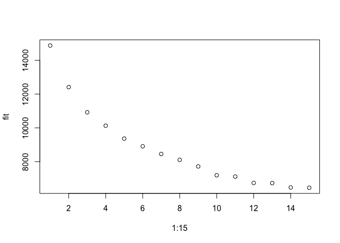

```r
set.seed(1)
fit <- 0
for(k in 1:15)
{clusterMovies4 <- kmeans(Data[,1:19], centers=k, nstart=20)
fit[k] <- clusterMovies4$tot.withinss}
plot(1:15,fit)
```

Let’s see the corresponding clusters:

```r
Cat2 <- matrix(0,nrow=19,ncol=10)
for(i in 1:19)
{Cat2[i,] <- tapply(Data[,i], clusterMovies2$cluster, mean)}
rownames(Cat2) <- colnames(Data)[1:19]
Cat2
```

```
##                    [,1]        [,2]         [,3]        [,4]        [,5]
## Action      0.184210526 0.080082136 0.0692520776 0.000000000 0.084291188
## Adventure   0.020775623 0.533880903 0.0526315789 0.007547170 0.013409962
## Animation   0.001385042 0.482546201 0.0049861496 0.026415094 0.005747126
## Children    0.000000000 0.901437372 0.0160664820 0.001886792 0.000000000
## Comedy      0.120498615 0.591375770 0.0000000000 0.060377358 0.201149425
## Crime       1.000000000 0.018480493 0.0000000000 0.005660377 0.019157088
## Documentary 0.002770083 0.000000000 0.0072022161 0.666037736 0.015325670
## Drama       0.833795014 0.088295688 1.0000000000 0.000000000 0.091954023
## Fantasy     0.004155125 0.365503080 0.0299168975 0.013207547 0.059386973
## Film-Noir   0.067867036 0.000000000 0.0094182825 0.013207547 0.000000000
## Horror      0.019390582 0.004106776 0.0005540166 0.000000000 1.000000000
## Musical     0.006925208 0.151950719 0.0227146814 0.075471698 0.011494253
## Mystery     0.170360111 0.016427105 0.0515235457 0.018867925 0.061302682
## Romance     0.065096953 0.053388090 0.0000000000 0.000000000 0.007662835
## Sci-Fi      0.009695291 0.078028747 0.0393351801 0.069811321 0.206896552
## Thriller    0.545706371 0.000000000 0.1368421053 0.000000000 0.000000000
## War         0.015235457 0.004106776 0.1257617729 0.064150943 0.001915709
## Western     0.009695291 0.010266940 0.0221606648 0.164150943 0.003831418
## IMAX        0.004155125 0.061601643 0.0055401662 0.024528302 0.017241379
##                    [,6]        [,7]        [,8]         [,9]       [,10]
## Action      0.836267606 0.077120823 1.000000000 0.0268074736 0.051369863
## Adventure   1.000000000 0.041773779 0.000000000 0.0406173842 0.010273973
## Animation   0.042253521 0.013496144 0.030141844 0.0089358245 0.010273973
## Children    0.019366197 0.006426735 0.008865248 0.0081234768 0.001712329
## Comedy      0.149647887 1.000000000 0.083333333 0.5483346872 0.065068493
## Crime       0.052816901 0.077763496 0.253546099 0.0178716491 0.044520548
## Documentary 0.000000000 0.002570694 0.001773050 0.0008123477 0.000000000
## Drama       0.195422535 0.306555270 0.157801418 0.6352558895 0.176369863
## Fantasy     0.223591549 0.032776350 0.028368794 0.0617384240 0.077054795
## Film-Noir   0.001760563 0.001285347 0.003546099 0.0040617384 0.013698630
## Horror      0.019366197 0.002570694 0.040780142 0.0064987815 0.710616438
## Musical     0.003521127 0.044987147 0.000000000 0.0609260764 0.005136986
## Mystery     0.038732394 0.014138817 0.051418440 0.0292445167 0.280821918
## Romance     0.073943662 0.000000000 0.040780142 1.0000000000 0.034246575
## Sci-Fi      0.294014085 0.040488432 0.324468085 0.0219333875 0.178082192
## Thriller    0.271126761 0.019280206 0.627659574 0.0333062551 1.000000000
## War         0.091549296 0.022493573 0.067375887 0.0438667750 0.006849315
## Western     0.058098592 0.021208226 0.035460993 0.0251827782 0.000000000
## IMAX        0.088028169 0.001928021 0.046099291 0.0024370431 0.006849315
```